# piper_posted_a_problem

This script was written to attempt to brute-force Piper's twitter question: Does there exist a pair of integers $(A,B)$ such that

$$\sqrt{A^2-4B} \notin \mathbb{Z}$$$$\sqrt{A^2/B-4} \notin \mathbb{Z}$$$$\sqrt{A^2B-4B^2} \in \mathbb{Z}$$

First, we'll import useful math functions

```python
import numpy as np
```

Then we'll write three functions that (attempt) to determine the three conditions above

```python
def first_condition(A,B):
    tolerance =  1e-12
    out     = False
    if A*A-4*B >= 0:
        radical = np.sqrt(A*A-4*B)
        ceil    = np.ceil(radical)
        floor   = np.floor(radical)
        if np.abs(radical-floor) > tolerance:
            out = True
        if np.abs(radical-ceil)  > tolerance:
            out = True
    return out

def second_condition(A,B):
    tolerance =  1e-12
    out     = False
    if A*A/B-4>=0:
        radical = np.sqrt(A*A/B-4)
        ceil    = np.ceil(radical)
        floor   = np.floor(radical)
        if np.abs(radical-floor) > tolerance:
            out = True
        if np.abs(radical-ceil)  > tolerance:
            out = True
    return out

def third_condition(A,B):
    tolerance =  1e-14
    out = False
    if A*A*B-4*B*B>=0:
        radical = np.sqrt(A*A*B-4*B*B)
        ceil    = np.ceil(radical)
        floor   = np.floor(radical)
        out     = False
        if np.abs(radical-floor) < tolerance:
            out = True
        if np.abs(radical-ceil)  < tolerance:
            out = True
    return out

def is_candidate(A,B):
    first = first_condition(A,B)
    second = second_condition(A,B)
    third = third_condition(A,B)
    if first*second*third > 0:
        return True
    else :
        return False
```

Now we'll test a huge square of integers, because I'm far too lazy to bother trying to prove anything directly today.

```python
candidate_integers = range(1,100)

for indx in candidate_integers:
    for jndx in candidate_integers:
        flag = is_candidate(indx,jndx)
        if flag:
            print([indx,jndx])
            break
```

```
[17, 68]
[20, 90]
[52, 98]
[68, 98]
```

We landed on a bunch of candidates. The first one seems to have worked. That's not to say I trust the rest, but It's worth repeating that I'm lazy. I'm going to try again over a much bigger square of integers, saving all the candidates into the list below. (At the end, I "cast" the list into a "numpy array." This is just so it's easier to plot the answers below.)

```python
candidates = [] #This is just a "list" that I'm going to add candiate pairs to

candidate_integers = range(1,1000)

for indx in candidate_integers:
    for jndx in candidate_integers:
        flag = is_candidate(indx,jndx)
        if flag:
            candidates.append([indx,jndx])

candidates = np.asanyarray(candidates)
```

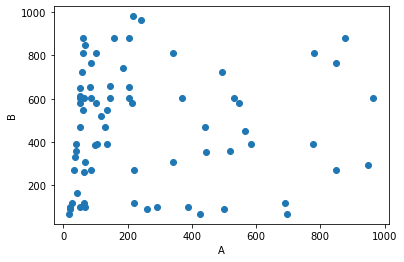

```python
import matplotlib.pyplot as plt

plt.scatter(candidates[:,0],candidates[:,1])
plt.xlabel('A')
plt.ylabel('B')
plt.show()
```

Addendum: We'll print off the prime factors of each of the solutions dumped out above. The following function is a simple prime factorization function (since I can't seem to find an obvious one in numpy.)

```python
def factors(nr):
    i = 2
    factors = []
    while i <= nr:
        if (nr % i) == 0:
            factors.append(i)
            nr = nr / i
        else:
            i = i + 1
    return factors

num_candidates = len(candidates)

for indx in range(num_candidates):
    A = candidates[indx,0]
    B = candidates[indx,1]
    print('A:' + str(factors(A)))
    print('B:' + str(factors(B)))
    print('--------------------')
```

```
A:[17]
B:[2, 2, 17]
--------------------
A:[2, 2, 5]
B:[2, 3, 3, 5]
--------------------
A:[2, 2, 5]
B:[2, 7, 7]
--------------------
A:[2, 13]
B:[3, 3, 13]
--------------------
A:[2, 17]
B:[2, 2, 2, 2, 17]
--------------------
A:[37]
B:[3, 3, 37]
--------------------
A:[2, 2, 2, 5]
B:[2, 2, 2, 3, 3, 5]
--------------------
A:[2, 2, 2, 5]
B:[2, 2, 2, 7, 7]
--------------------
A:[41]
B:[2, 2, 41]
--------------------
A:[2, 5, 5]
B:[5, 11, 11]
--------------------
A:[3, 17]
B:[2, 2, 3, 3, 17]
--------------------
A:[2, 2, 13]
B:[2, 7, 7]
--------------------
A:[2, 2, 13]
B:[2, 2, 3, 3, 13]
--------------------
A:[2, 2, 13]
```

[output cut: 167 more lines]

```
A:[2, 5, 5, 17]
B:[2, 2, 2, 2, 17]
--------------------
A:[2, 5, 5, 17]
B:[3, 3, 5, 17]
--------------------
A:[2, 2, 3, 73]
B:[2, 3, 3, 7, 7]
--------------------
A:[13, 73]
B:[2, 2, 73]
--------------------
A:[5, 193]
B:[5, 11, 11]
--------------------
```